# TITANIC DATA SET -SURVIVOR PREDICTOR

YUVA BHARATHI

4 December 2018

## Problem Statement:

*Let us take the Titanic Data set and build a model which will predict the survival probability - whether or not a passenger would have survived if travelled on Titanic. This can be a prototype to predict accident probability / Air crash Probability predictor and many other such use cases.*

## Data Set:

*Titanic data set contains various data points about each passenger who was onboard in the Titanic Ship. The data set aslo contains whether the passenger survived the crash or not.*

## Import Data

```r
df<-read.csv('C:\\Users\\Windows\\Desktop\\data sci\\06 Classification\\Titanic R\\titanic_train.csv')
head(df)
```

```
##   PassengerId Survived Pclass
## 1           1        0      3
## 2           2        1      1
## 3           3        1      3
## 4           4        1      1
## 5           5        0      3
## 6           6        0      3
##                                                  Name    Sex Age SibSp
## 1                             Braund, Mr. Owen Harris   male  22     1
## 2 Cumings, Mrs. John Bradley (Florence Briggs Thayer) female  38     1
## 3                              Heikkinen, Miss. Laina female  26     0
## 4        Futrelle, Mrs. Jacques Heath (Lily May Peel) female  35     1
## 5                            Allen, Mr. William Henry   male  35     0
## 6                                    Moran, Mr. James   male  NA     0
##   Parch           Ticket    Fare Cabin Embarked
## 1     0        A/5 21171  7.2500              S
## 2     0         PC 17599 71.2833   C85        C
## 3     0 STON/O2. 3101282  7.9250              S
## 4     0           113803 53.1000  C123        S
## 5     0           373450  8.0500              S
## 6     0           330877  8.4583              Q
```

## Exploratory Data Analysis (EDA)

```r
length(df)
```

```
## [1] 12
```

```r
df[,6:8]
```

[output not shown]

[output cut: 877 more lines]

```r
df['Pclass']
```

[output not shown]

[output cut: 877 more lines]

# Find missing data:

*Let us explore how much missing data we have,*

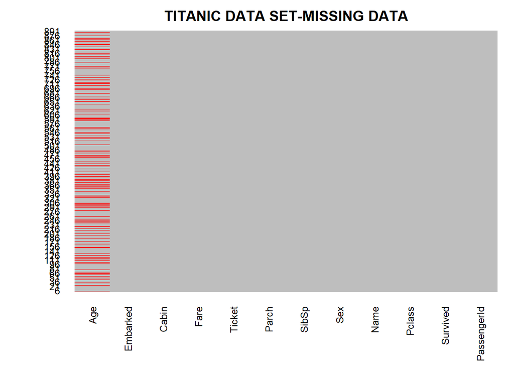

```r
library(Amelia)
missmap(df,main='TITANIC DATA SET-MISSING DATA',col=c('red','gray'),legend=FALSE)
```

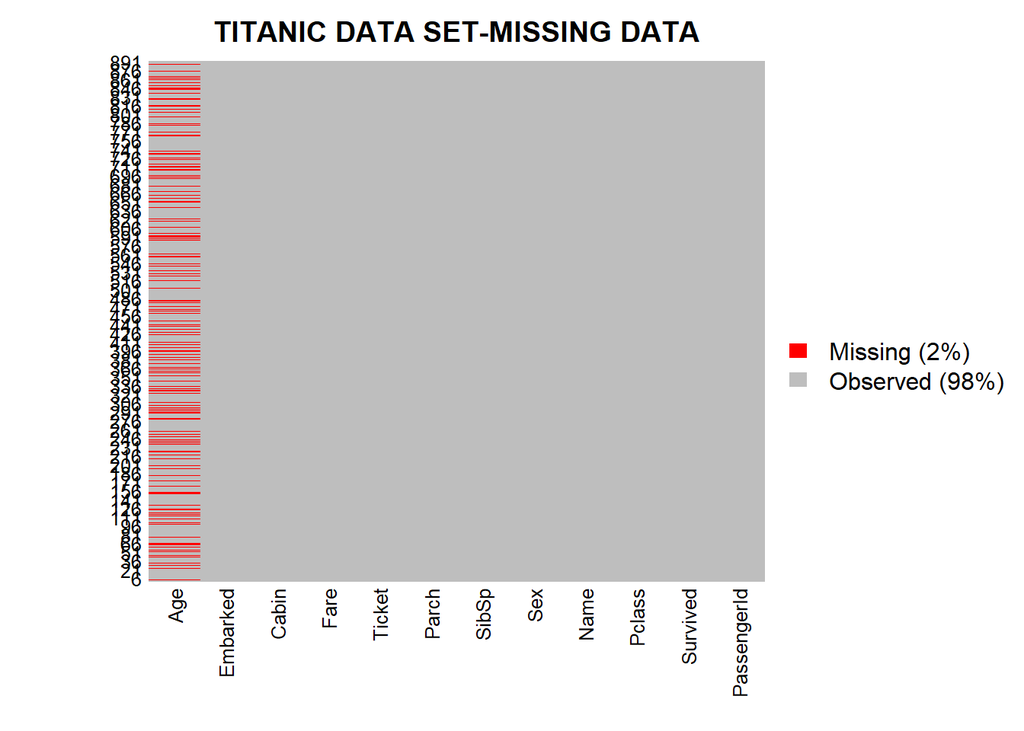

```r
missmap(df,main='TITANIC DATA SET-MISSING DATA',col=c('red','gray'),legend=TRUE)
```

# Data Visualization

*1.Survivors Histogram*

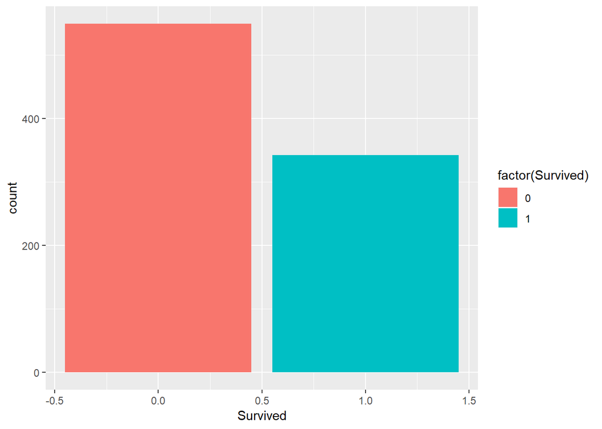

```r
library(ggplot2)
pl<-ggplot(df,aes(Survived))+geom_bar(aes(fill=factor(Survived)))
pl
```

*2.Passengers Count Class wise Distribution*

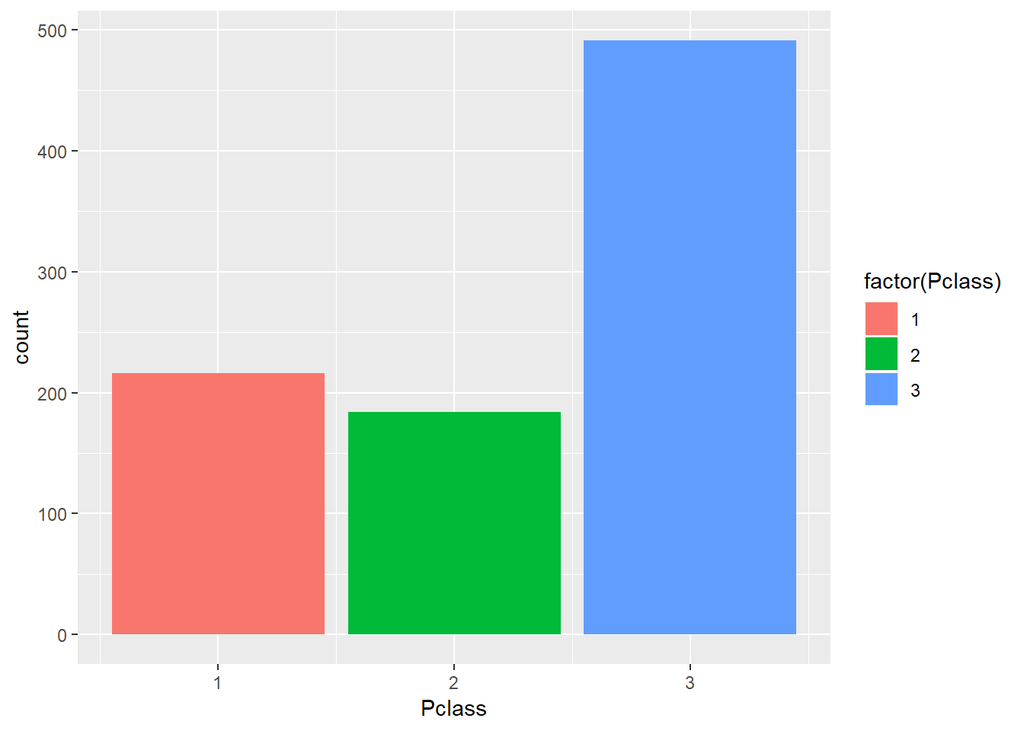

```r
library(ggplot2)
pl<-ggplot(df,aes(Pclass))+geom_bar(aes(fill=factor(Pclass)))
pl
```

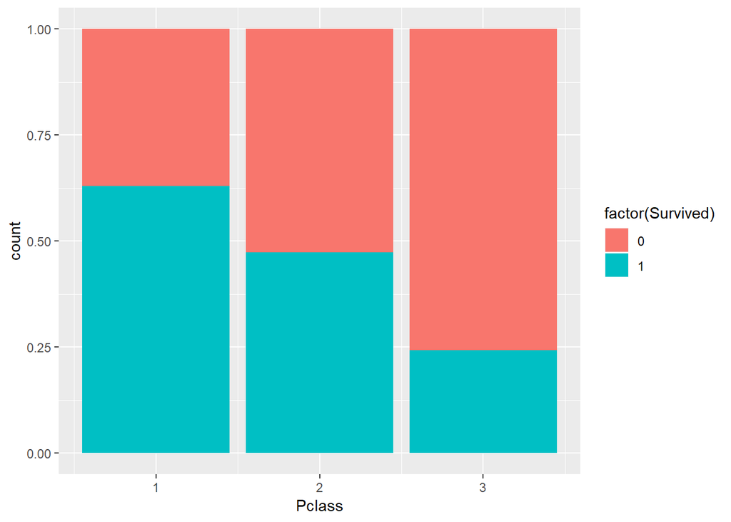

```r
pl<-ggplot(df,aes(Pclass))+geom_bar(aes(fill=factor(Survived)),position='fill')
pl
```

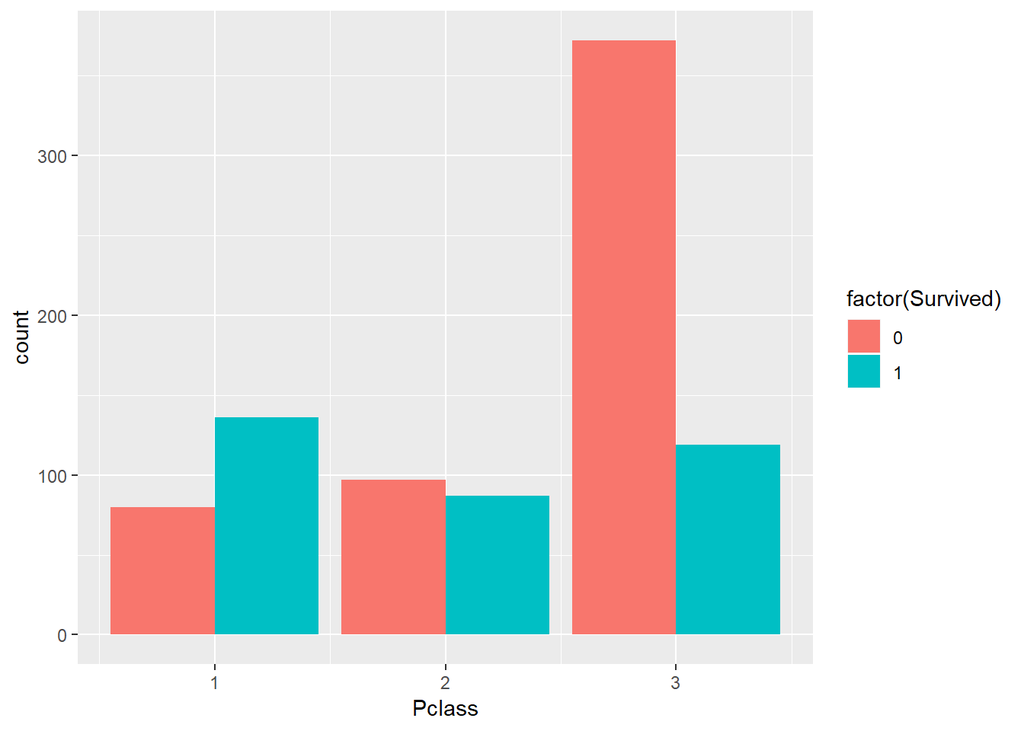

```r
pl<-ggplot(df,aes(Pclass))+geom_bar(aes(fill=factor(Survived)),position='dodge')
pl
```

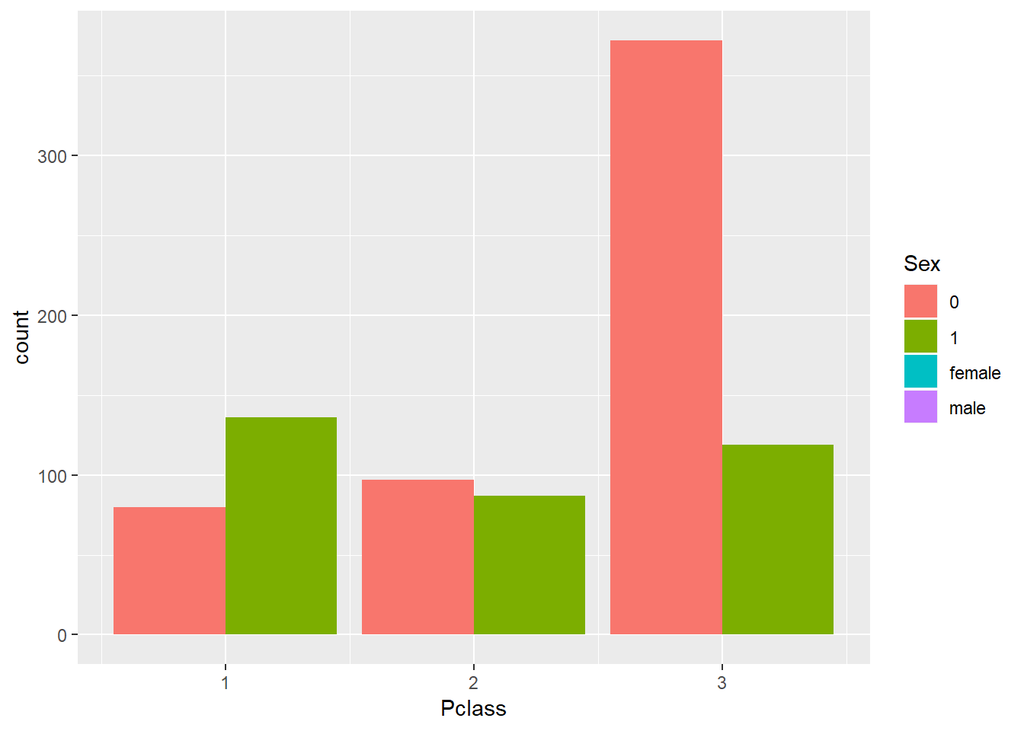

```r
pl<-ggplot(df,aes(Pclass))+geom_bar(aes(fill=Sex),position='fill')+geom_bar(aes(fill=factor(Survived)),position='dodge')
pl
```

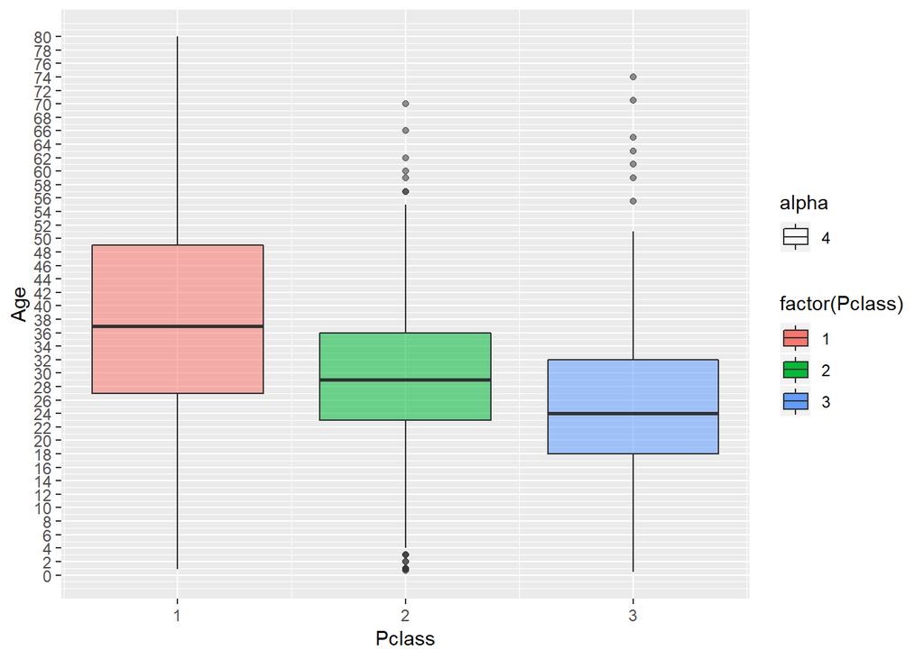

```r
pl<-ggplot(df,aes(Pclass,Age))+geom_boxplot(aes(group=Pclass,fill=factor(Pclass),alpha=4))
pl+scale_y_continuous(breaks=seq(min(0),max(80),by=2))
```

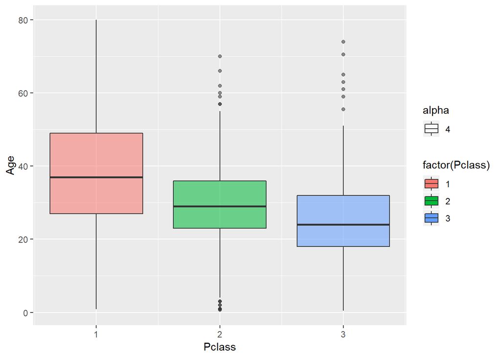

```r
pl
```

*We shall use these average age values to impute based on Pclass for Age. Because we see that avg age is different for each class.*

```r
fill_age<-function(age,class)
{
  out<-age
  for(i in 1:length(age))
  {
   if(is.na(age[i]))
   {
     if(class[i]==1)
     {
       out[i]<-37
     }
     else if(class[i]==2)
     {
       out[i]<-29

     }
     else if(class[i]==3)
     {
       out[i]<-24
     }
   }

  else
  {
    out[i]<-age[i]
  }
}
return(out)
}
```

***Rechecking for Missing data:***

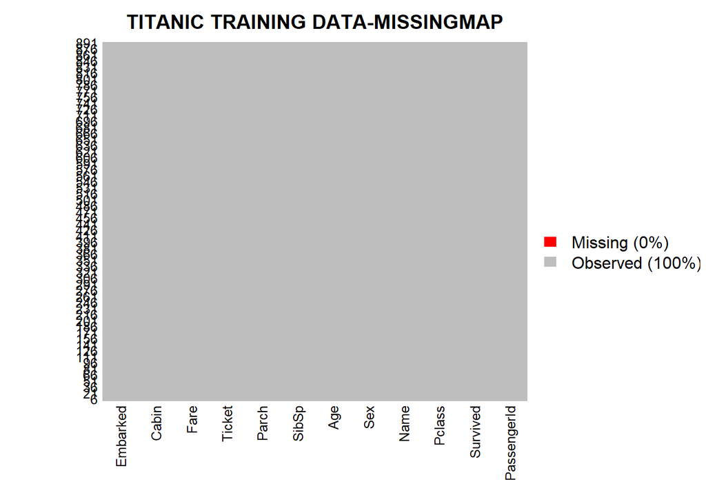

```r
z<-fill_age(df$Age,df$Pclass)
df$Age<-z
missmap(df,main='TITANIC TRAINING DATA-MISSINGMAP',col=c('red','gray'),legend=TRUE)
```

*Now there is no missing values in the data set.*

*Rather than using all the columns to build the model, let us use specific columns as input signals for the model.*

```r
df <- df[,!(colnames(df) %in% c('PassengerId','Name','Ticket','Cabin'))]
```

## Train and Test Data fit:

```r
library(caTools)
set.seed(101)

split=sample.split(df$Survived,SplitRatio=0.70)
train_data=subset(df,split==TRUE)
test_data=subset(df,split==FALSE)
```

## Logistic Regression Classifier

*To build the first classifier model using the Logistic Regression Algorithm.* *The function for Logistic Regression model is glm()*

*Building the Model:*

```r
log.model <- glm(formula=Survived ~ . , family = binomial(link='logit'),data = train_data)
```

***Prediction for test data:***

```r
fitted.probabilities <- predict(log.model,newdata=test_data,type='response')
```

*Accuracy Measurement:*

```r
fitted.results <- ifelse(fitted.probabilities > 0.5,1,0)
misClasificError <- mean(fitted.results != test_data$Survived)
print(paste('Accuracy',1-misClasificError))
```

```
## [1] "Accuracy 0.783582089552239"
```

*The LR Classifier Model we have built is 78.35 % accurate in predicting if a new passenger will survive the journey on Titanic.*

## Decision Tree Model

*Let us now build the next classifier using Decision Trees algorithm*

*Library : rpart library*

```r
library(rpart)
dectree<-rpart(Survived~.,method='class',data=train_data)
```

*Test the Model: Use predict() to predict the survival value on the test data.*

```r
dectree.pred<-predict(dectree,test_data)
```

*Check the Head of the predicted values.It actually have two columns with the probabilities.*

```r
head(dectree.pred)
```

```
##             0         1
## 4  0.07826087 0.9217391
## 6  0.83547558 0.1645244
## 12 0.07826087 0.9217391
## 21 0.83547558 0.1645244
## 22 0.83547558 0.1645244
## 24 0.83547558 0.1645244
```

*** Function to convert these two columns into one column to match the original “1/0” Label for the Survival column.***

```r
dectree.pred<-as.data.frame(dectree.pred)

joiner<-function(x)
{
  if(x>0.5)
  {
   return(1)
  } else{
    return(0)
  }
}
```

*Apply function to each of the row in the prediction result*

```r
dectree.pred$Survival<-sapply(dectree.pred$'1',joiner)
```

```r
head(dectree.pred$Survival)
```

```
## [1] 1 0 1 0 0 0
```

*Calculate the accuracy By comparing the prediction result with the actual result*

```r
misClasificError<-mean(dectree.pred$Survival!=test_data$Survived)
print(misClasificError)
```

```
## [1] 0.1865672
```

```r
print(1-misClasificError)
```

```
## [1] 0.8134328
```

```r
table(dectree.pred$Survival,test_data$Survived)
```

```
##
##       0   1
##   0 147  32
##   1  18  71
```

```r
print(paste('Accuracy',1-misClasificError))
```

```
## [1] "Accuracy 0.813432835820896"
```

*The Decision Tree Classifier Model we have built is 81.3 % Bold accurate in predicting if a new passenger will survive the journey.*

## Random Forest Classifier

*Library: randonForest()* ***Build The Model using Train Data:***

```r
library(randomForest)
rf<-randomForest(Survived~.,data=train_data)
rf.pred<-predict(rf,test_data)
head(rf.pred)
```

```
##          4          6         12         21         22         24
## 0.96776276 0.12661823 0.72751358 0.10680513 0.06088564 0.39369278
```

```r
joiner<-function(x)
{
  if(x>0.5)
  {
   return(1)
  } else{
    return(0)
  }
}
```

```r
rf.pred<-sapply(rf.pred,joiner)
```

```r
table(rf.pred,test_data$Survived)
```

```
##
## rf.pred   0   1
##       0 150  30
##       1  15  73
```

*Calculate the accuracy:*

```r
misClasificError<-mean(rf.pred!=test_data$Survived)
print(misClasificError)
```

```
## [1] 0.1679104
```

```r
print(1-misClasificError)
```

```
## [1] 0.8320896
```

```r
print(paste('Accuracy',1-misClasificError))
```

```
## [1] "Accuracy 0.832089552238806"
```

*The Random forest Classifier Model we have built is 83.2 % accurate in predicting if a passenger will survive the travel or not.*

## KNN Algorithm Classifier

*Data needs to be scaled before we pass it on to building the KNN model*

```r
titanic_std<-scale(df[,!(colnames(df)%in%c('Embarked','Sex','Survived'))])
z<-data.frame(titanic_std)
head(z)
```

```
##       Pclass        Age      SibSp      Parch       Fare
## 1  0.8269128 -0.5335340  0.4325504 -0.4734077 -0.5021631
## 2 -1.5652278  0.6745117  0.4325504 -0.4734077  0.7864036
## 3  0.8269128 -0.2315226 -0.4742788 -0.4734077 -0.4885799
## 4 -1.5652278  0.4480031  0.4325504 -0.4734077  0.4204941
## 5  0.8269128  0.4480031 -0.4742788 -0.4734077 -0.4860644
## 6  0.8269128 -0.3825283 -0.4742788 -0.4734077 -0.4778481
```

*Add the Survived column to the standardized data frame*

```r
z$Survived<-df$Survived
head(z)
```

```
##       Pclass        Age      SibSp      Parch       Fare Survived
## 1  0.8269128 -0.5335340  0.4325504 -0.4734077 -0.5021631        0
## 2 -1.5652278  0.6745117  0.4325504 -0.4734077  0.7864036        1
## 3  0.8269128 -0.2315226 -0.4742788 -0.4734077 -0.4885799        1
## 4 -1.5652278  0.4480031  0.4325504 -0.4734077  0.4204941        1
## 5  0.8269128  0.4480031 -0.4742788 -0.4734077 -0.4860644        0
## 6  0.8269128 -0.3825283 -0.4742788 -0.4734077 -0.4778481        0
```

*Train & Test Data Split from the scaled data*

```r
library(class)
set.seed(101)
split=sample.split(z$Survived,SplitRatio = 0.7)

train_data=subset(z,split==TRUE)
test_data=subset(z,split==FALSE)
```

```r
train_data[,]
```

[output not shown]

[output cut: 609 more lines]

```r
test_data[,]
```

[output not shown]

[output cut: 254 more lines]

k-Nearest Neighbour Classification knn(train, test, cl, k = 1, l = 0, prob = FALSE, use.all = TRUE) *Build the model:*

```r
library(class)
knn_predict<-knn(train_data[,1:5],test_data[,1:5],train_data$Survived,k=1)
head(knn_predict)
```

```
## [1] 0 0 0 1 0 1
## Levels: 0 1
```

*Check the Accuracy:*

```r
misClasificError<-mean(knn_predict!=test_data$Survived)
print(misClasificError)
```

```
## [1] 0.3544776
```

```r
print(paste('Accuracy',1-misClasificError))
```

```
## [1] "Accuracy 0.645522388059701"
```

*Trying with k=3, considering 3 neighbors to predict the result:*

```r
knn_predict<-knn(train_data[1:5],test_data[1:5],train_data$Survived,k=3)
head(knn_predict)
```

```
## [1] 1 0 0 1 1 1
## Levels: 0 1
```

```r
misClasificError<-mean(knn_predict!=test_data$Survived)
print(misClasificError)
```

```
## [1] 0.3283582
```

```r
print(paste('Accuracy',1-misClasificError))
```

```
## [1] "Accuracy 0.671641791044776"
```

*We observe that the accuracy keeps improving. Let us try to find the optimum value of K.*

## CODE TO PRINT ERROR RATE FOR K=1 TO 20

```r
knn.predict=NULL
error=NULL
for(i in 1:20)
  {
  set.seed(101)
  knn_predict<-knn(train_data[1:5],test_data[1:5],train_data$Survived,k=i)
  error[i]<-mean(knn_predict!=test_data$Survived)
}
print(error)
```

```
##  [1] 0.3432836 0.3656716 0.3320896 0.3320896 0.2947761 0.3059701 0.2947761
##  [8] 0.3059701 0.3022388 0.2985075 0.2723881 0.2798507 0.2910448 0.2798507
## [15] 0.2835821 0.2723881 0.2761194 0.2835821 0.2835821 0.2761194
```

*Elbow Method:* *We can plot out the various error rates for the K values. We should see an “elbow” indicating that we don’t get a decrease in error rate for using a higher K. This is a good cut-off point:* *To plot some data, we need to have a data frame. Two columns - k value, error rate.*

```r
library(ggplot2)
neighbor<-1:20
error.rate<-data.frame(neighbor,error)
error.rate
```

```
##    neighbor     error
## 1         1 0.3432836
## 2         2 0.3656716
## 3         3 0.3320896
## 4         4 0.3320896
## 5         5 0.2947761
## 6         6 0.3059701
## 7         7 0.2947761
## 8         8 0.3059701
## 9         9 0.3022388
## 10       10 0.2985075
## 11       11 0.2723881
## 12       12 0.2798507
## 13       13 0.2910448
## 14       14 0.2798507
## 15       15 0.2835821
## 16       16 0.2723881
## 17       17 0.2761194
## 18       18 0.2835821
## 19       19 0.2835821
## 20       20 0.2761194
```

*Plot the K value Vs error Rate :*

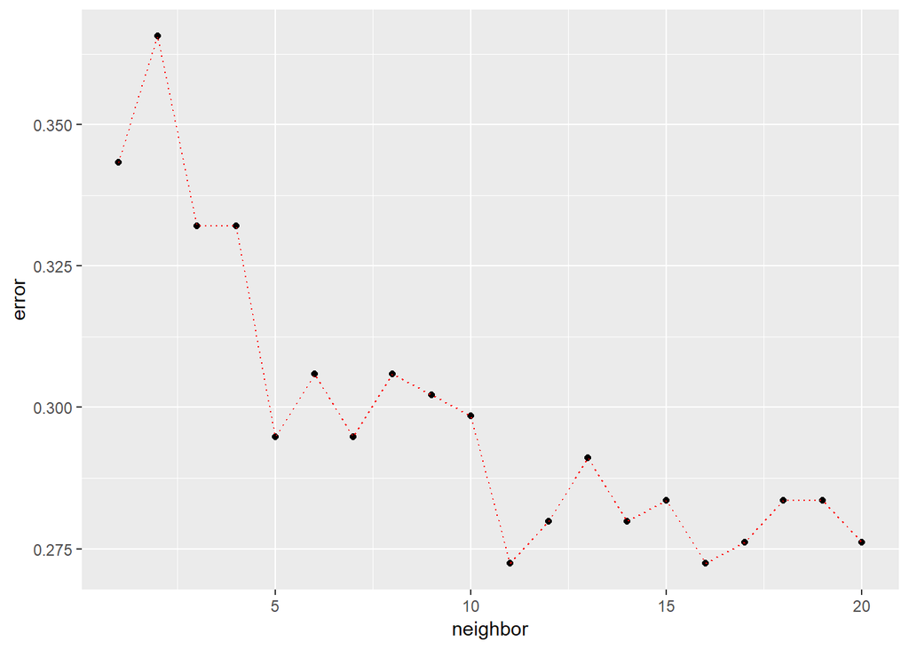

```r
ggplot(error.rate,aes(neighbor,error))+geom_point()+geom_line(lty="dotted",color='red')
```

*From the graph we observe that k=11 has the least error. So let us find the accuracy for k=11.*

```r
  set.seed(101)
  knn_predict<-knn(train_data[1:5],test_data[1:5],train_data$Survived,k=11)
  error<-mean(knn_predict!=test_data$Survived)

print(error)
```

```
## [1] 0.2723881
```

```r
print(paste('Accuracy is',1-error))
```

```
## [1] "Accuracy is 0.727611940298508"
```

```r
table(knn_predict,test_data$Survived)
```

```
##
## knn_predict   0   1
##           0 135  43
##           1  30  60
```

*The Accuracy from the KNN classifier with K Value=11 is 72.7 %.*

## Conclusion:

*The summary of the accuracy from the different classifiers built:* *Logistic Regression - 78.35 %* *Decision Trees - 81.3 %* *Random Forest - 83 %* *KNN Classifier - 72.7 %* *Either we can conclude that Random Forest is the best classifer in this case.*